# Q3

*requirements*

*Import data*

```r
file_path <- "WisconsinDiagnosislrn.sec"
data <- read.table(file_path, sep = "\t", header = FALSE, comment.char = "%", skip = 1)

column_names <- c("Key", "Mean_radius", "Mean_texture", "Mean_perimeter", "Mean_area", "Mean_smoothness", "Mean_compactness", "Mean_concavity", "Mean_concave_points", "Mean_symmetry", "Mean_fractal_dimension",
                  "SE_radius", "SE_texture", "SE_perimeter", "SE_area", "SE_smoothness", "SE_compactness", "SE_concavity", "SE_concave_points", "SE_symmetry", "SE_fractal_dimension",
                  "Worst_radius", "Worst_texture", "Worst_perimeter", "Worst_area", "Worst_smoothness", "Worst_compactness", "Worst_concavity", "Worst_concave_points", "Worst_symmetry", "Worst_fractal_dimension")
colnames(data) <- column_names

head(data)
```

|  | Key | Mean_radius | Mean_texture | Mean_perimeter | Mean_area | Mean_smoothness | Mean_compactness | Mean_concavity | Mean_concave_points | Mean_symmetry | Mean_fractal_dimension | SE_radius | SE_texture | SE_perimeter | SE_area | SE_smoothness | SE_compactness | SE_concavity | SE_concave_points | SE_symmetry | SE_fractal_dimension | Worst_radius | Worst_texture | Worst_perimeter | Worst_area | Worst_smoothness | Worst_compactness | Worst_concavity | Worst_concave_points | … |
| --- | --- | --- | --- | --- | --- | --- | --- | --- | --- | --- | --- | --- | --- | --- | --- | --- | --- | --- | --- | --- | --- | --- | --- | --- | --- | --- | --- | --- | --- | --- |
| 1 | 1001 | 17.99 | 10.38 | 122.80 | 1001.0 | 0.11840 | 0.27760 | 0.3001 | 0.14710 | 0.2419 | 0.07871 | 1.0950 | 0.9053 | 8.589 | 153.40 | 0.006399 | 0.04904 | 0.05373 | 0.01587 | 0.03003 | 0.006193 | 25.38 | 17.33 | 184.60 | 2019.0 | 0.1622 | 0.6656 | 0.7119 | 0.2654 | … |
| 2 | 1002 | 20.57 | 17.77 | 132.90 | 1326.0 | 0.08474 | 0.07864 | 0.0869 | 0.07017 | 0.1812 | 0.05667 | 0.5435 | 0.7339 | 3.398 | 74.08 | 0.005225 | 0.01308 | 0.01860 | 0.01340 | 0.01389 | 0.003532 | 24.99 | 23.41 | 158.80 | 1956.0 | 0.1238 | 0.1866 | 0.2416 | 0.1860 | … |
| 3 | 1003 | 19.69 | 21.25 | 130.00 | 1203.0 | 0.10960 | 0.15990 | 0.1974 | 0.12790 | 0.2069 | 0.05999 | 0.7456 | 0.7869 | 4.585 | 94.03 | 0.006150 | 0.04006 | 0.03832 | 0.02058 | 0.02250 | 0.004571 | 23.57 | 25.53 | 152.50 | 1709.0 | 0.1444 | 0.4245 | 0.4504 | 0.2430 | … |
| 4 | 1004 | 11.42 | 20.38 | 77.58 | 386.1 | 0.14250 | 0.28390 | 0.2414 | 0.10520 | 0.2597 | 0.09744 | 0.4956 | 1.1560 | 3.445 | 27.23 | 0.009110 | 0.07458 | 0.05661 | 0.01867 | 0.05963 | 0.009208 | 14.91 | 26.50 | 98.87 | 567.7 | 0.2098 | 0.8663 | 0.6869 | 0.2575 | … |
| 5 | 1005 | 20.29 | 14.34 | 135.10 | 1297.0 | 0.10030 | 0.13280 | 0.1980 | 0.10430 | 0.1809 | 0.05883 | 0.7572 | 0.7813 | 5.438 | 94.44 | 0.011490 | 0.02461 | 0.05688 | 0.01885 | 0.01756 | 0.005115 | 22.54 | 16.67 | 152.20 | 1575.0 | 0.1374 | 0.2050 | 0.4000 | 0.1625 | … |
| 6 | 1006 | 12.45 | 15.70 | 82.57 | 477.1 | 0.12780 | 0.17000 | 0.1578 | 0.08089 | 0.2087 | 0.07613 | 0.3345 | 0.8902 | 2.217 | 27.19 | 0.007510 | 0.03345 | 0.03672 | 0.01137 | 0.02165 | 0.005082 | 15.47 | 23.75 | 103.40 | 741.6 | 0.1791 | 0.5249 | 0.5355 | 0.1741 | … |

```r
NA
NA
```

*Scaling and other preprocessing*

```r
scale2 <- function(x) {
  #Scale all columns, [0,1]
  return ((x - min(x)) / (max(x) - min(x)))
}

data.sc2 <- as.data.frame(lapply(data, function(x) {
  if (is.numeric(x)) {
    return(scale2(x))
  } else {
    return(x)
  }
}))

data.sc2 = as.matrix(data.sc2)
data.sc = scale(data)

pca_result <- prcomp(data[, -1], scale. = TRUE)
pca_transformed_data <- pca_result$x
data.pca <- as.matrix(cbind(data[, 1], pca_transformed_data))

data.current <- data.sc2 ## Using Scale2() data now
```

*Comments* We tested scaling the data with: - the built in scale() function that sets values approx between -2,2 - a simple scaling function scale2() that scales data to be between 0,1 (Intuitively this works better as for euclidian distances) - a quick PCA, to also help with correlation

[output not shown]

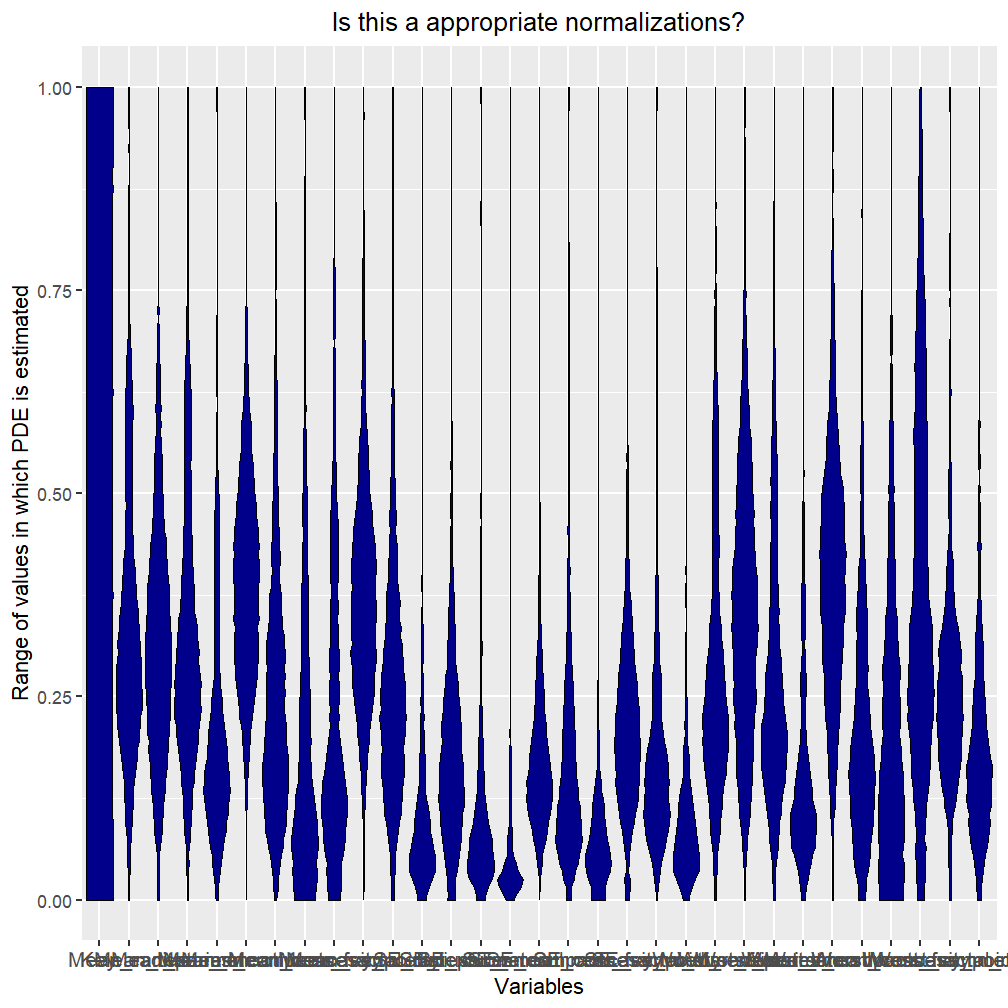

```r
MDplot(data.current)+ggplot2::ggtitle(
  'Is this a appropriate normalizations?')
```

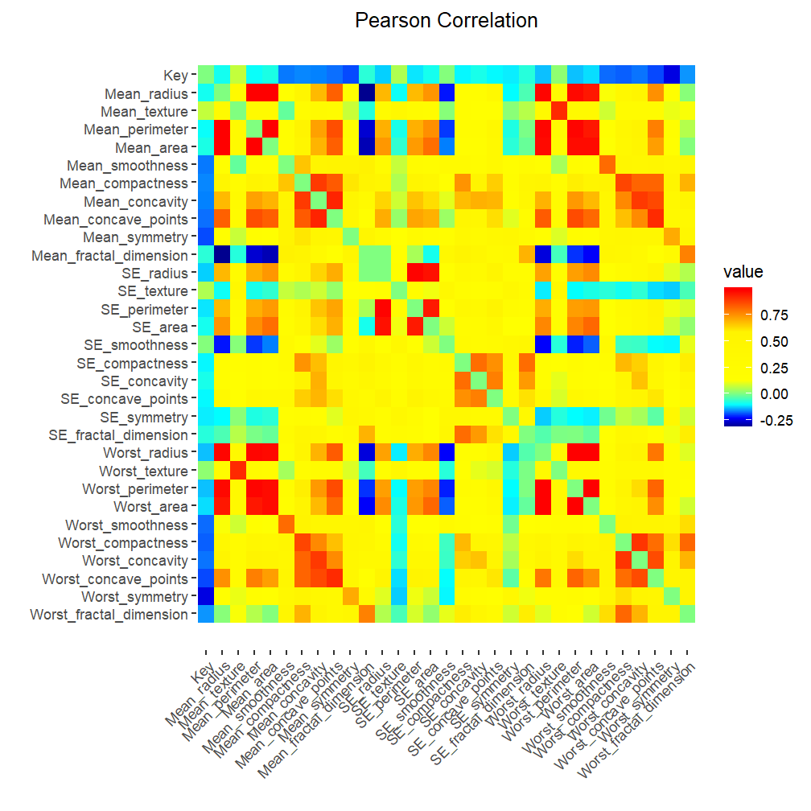

```r
cc=cor(data.current)
diag(cc)=0
DataVisualizations::Pixelmatrix(cc,
      main = 'Pearson Correlation')
```

*COmments* Many features are extremely correlated, we need to do something about them. We try PCA and removing features with correlation coefficient > cutoff.

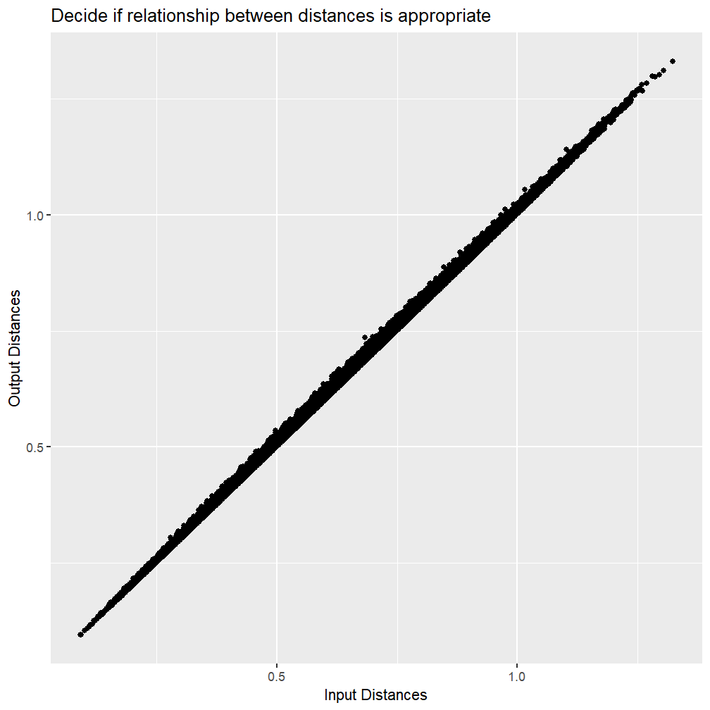

```r
OtherDistance=as.matrix(parallelDist::parallelDist(
  data.current,method = 'geodesic')
  )
OutputDim=50
Trans=ProjectionBasedClustering::MDS(
  DataOrDistances = OtherDistance,
  OutputDimension = OutputDim)$ProjectedPoints

DataVisualizations::Sheparddiagram(OtherDistance,
  as.matrix(dist(Trans)),main =
  'Decide if relationship between distances is appropriate'
  )
```

```
Subordinate clustering package (ScatterDensity) is missing. Switching to MASS::kde2d density estimation.
            Please install the package which is defined in "Suggests".
Subordinate clustering package (ScatterDensity) is missing. Switching to MASS::kde2d density estimation.
            Please install the package which is defined in "Suggests".
```

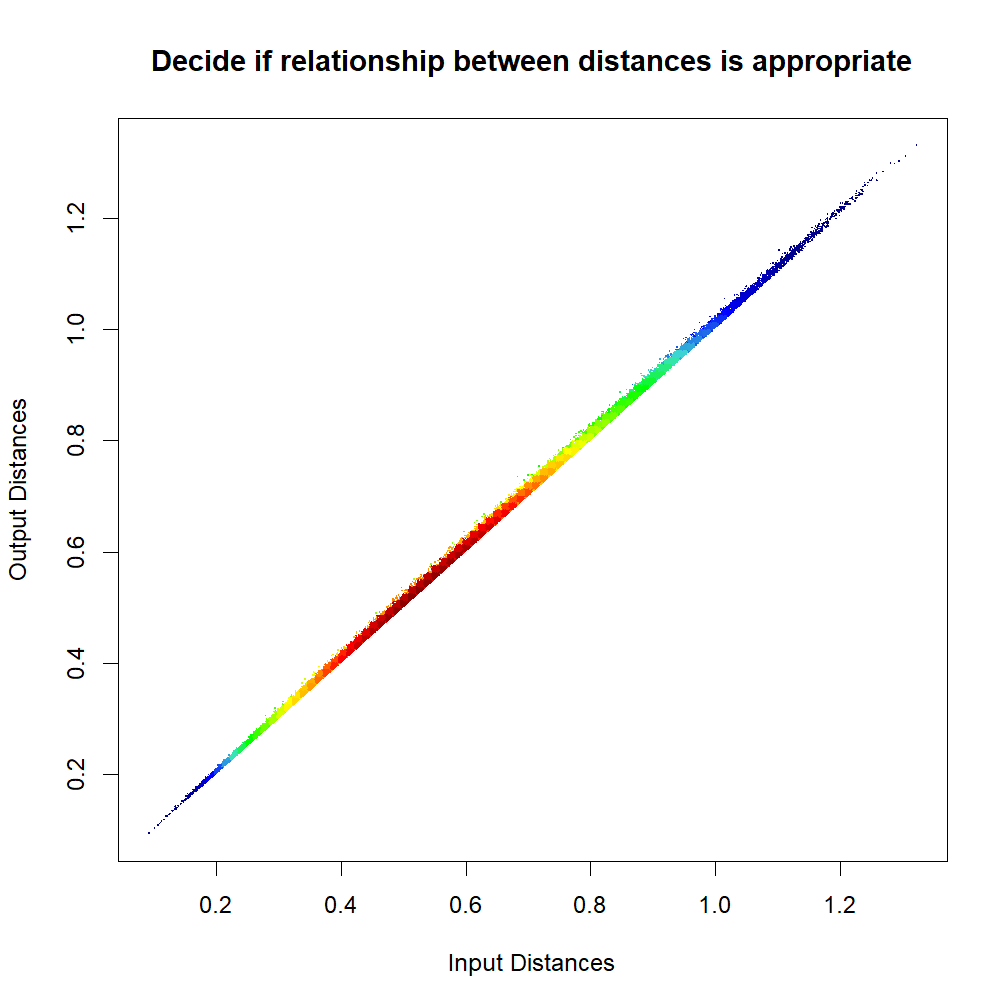

```r
V=DataVisualizations::ShepardDensityScatter(OtherDistance,
  as.matrix(dist(Trans)),main =
  'Decide if relationship between distances is appropriate'
  )
```

*Comments* Relationship appears appropriate. Values form a near straight line.

```r
high_cor_features <- findCorrelation(cc, cutoff = 0.75)
data.without_correlated <- data.current[, -high_cor_features]
data.without_correlated <- data.without_correlated[,-1]
```

*Comments* - Remove 1 of each pair of features with correlation > 0.75 - This leaves us with 12 features, which seems appropriate for approx 600 data-points.

[output not shown]

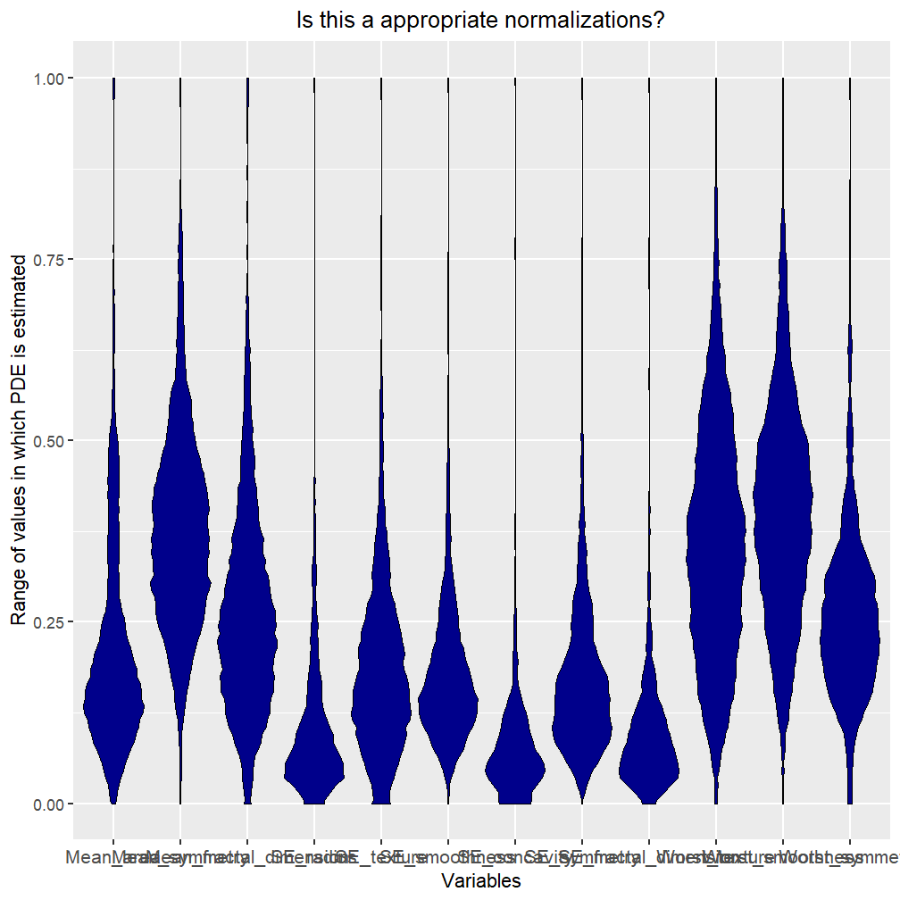

```r
MDplot(data.without_correlated)+ggplot2::ggtitle(
  'Is this a appropriate normalizations?')
```

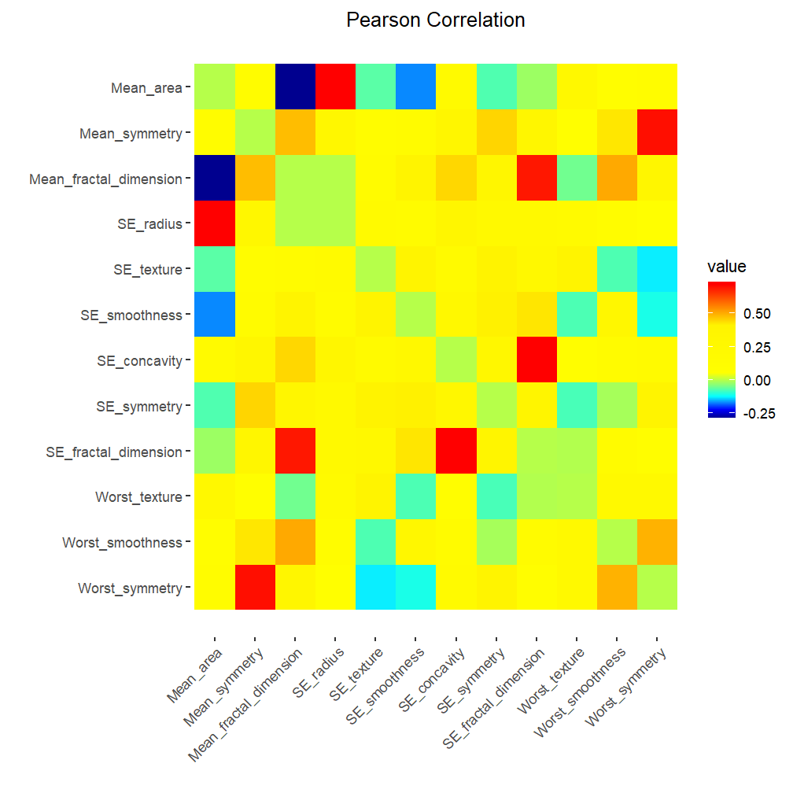

```r
cc=cor(data.without_correlated)
diag(cc)=0
DataVisualizations::Pixelmatrix(cc,
      main = 'Pearson Correlation')
```

*Comments* New correlation analysis looks better.

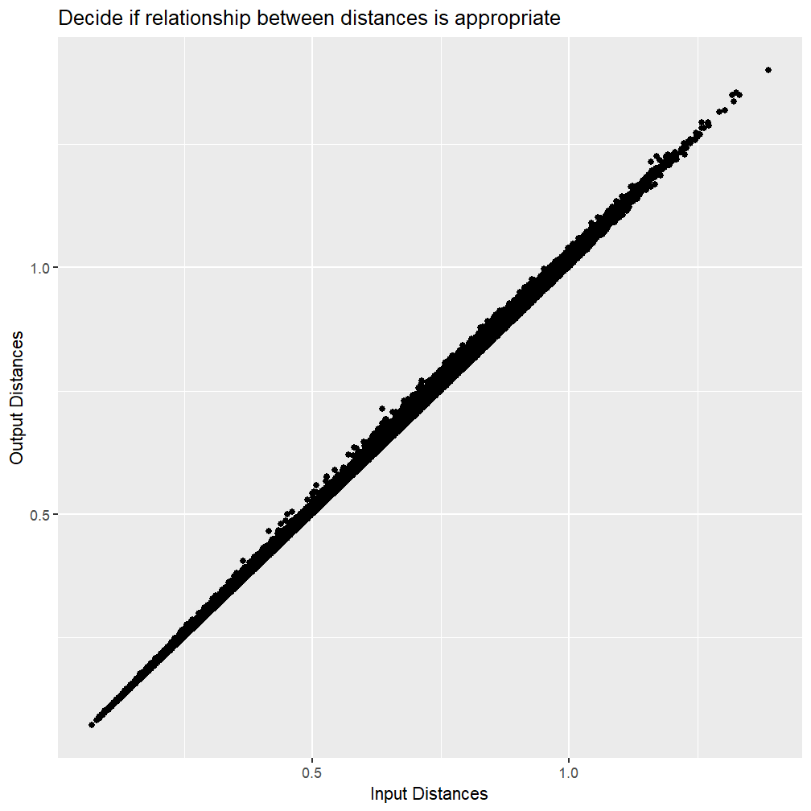

```r
OtherDistance=as.matrix(parallelDist::parallelDist(
  data.without_correlated,method = 'geodesic')
  )
OutputDim=50
Trans=ProjectionBasedClustering::MDS(
  DataOrDistances = OtherDistance,
  OutputDimension = OutputDim)$ProjectedPoints

DataVisualizations::Sheparddiagram(OtherDistance,
  as.matrix(dist(Trans)),main =
  'Decide if relationship between distances is appropriate'
  )
```

```
Subordinate clustering package (ScatterDensity) is missing. Switching to MASS::kde2d density estimation.
            Please install the package which is defined in "Suggests".
Subordinate clustering package (ScatterDensity) is missing. Switching to MASS::kde2d density estimation.
            Please install the package which is defined in "Suggests".
```

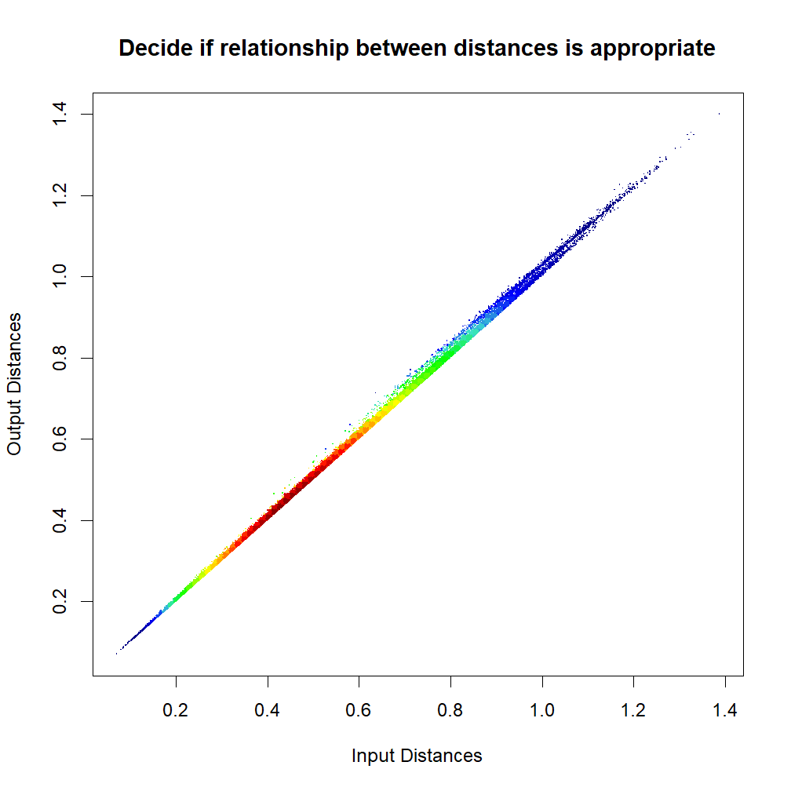

```r
V=DataVisualizations::ShepardDensityScatter(OtherDistance,
  as.matrix(dist(Trans)),main =
  'Decide if relationship between distances is appropriate'
  )
```

```r
res = esomTrain(Data = data.without_correlated,
                Lines = 60,
                Columns = 100,
                Epochs = 100,
                Toroid = T,
                NeighbourhoodFunction = "mexicanhat",
                StartLearningRate = 0.7,
                EndLearningRate = 0.01,
                StartRadius = 40,
                EndRadius = 4,
                NeighbourhoodCooling = "linear",
                LearningRateCooling = "linear",
                UmatrixForEsom = T)
```

```r
UmatrixInformation = Umatrix::umatrixForEsom(
  res$Weights,
  Columns = res$Columns,
  Lines = res$Lines,
  Toroid = T
)

GeneralizedUmatrix::plotTopographicMap(UmatrixInformation,
                                       res$BestMatches,
                                       Toroid = T

)
```

[output not shown]

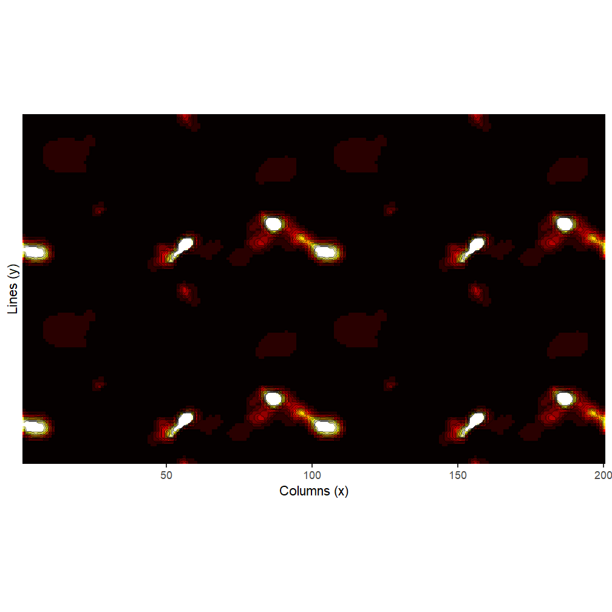

```r
Pmatrix = pmatrixForEsom(data.without_correlated,
                         res$Weights,
                         res$Lines,
                         res$Columns,
                         res$Toroid)

plotMatrix(Pmatrix, ColorStyle = "Pmatrix", Toroid = T)
```

```r
Ustarmatrix = ustarmatrixCalc(res$Umatrix, Pmatrix)
```

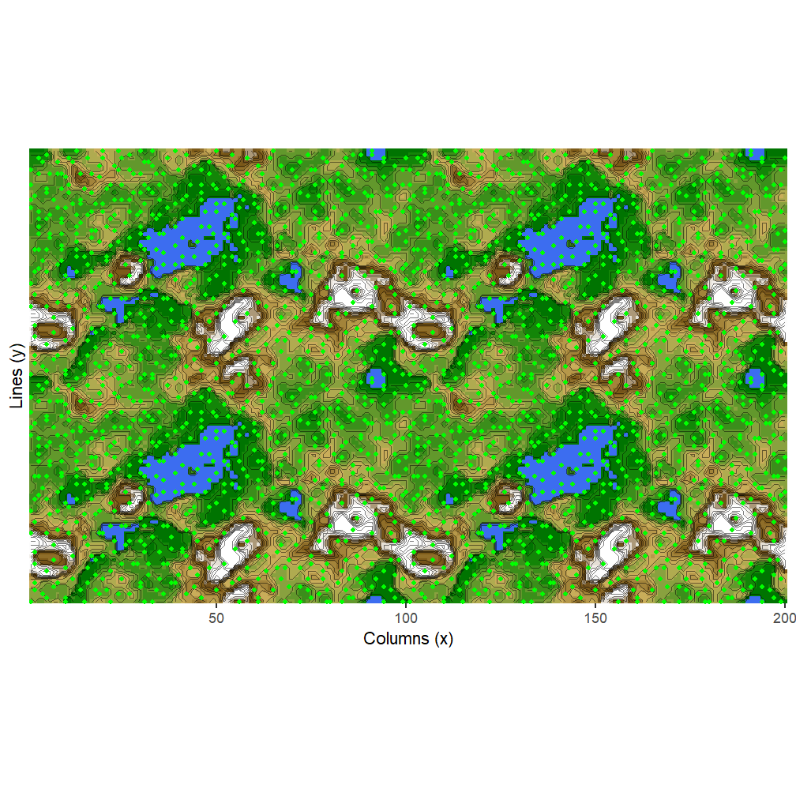

```r
plotMatrix(Ustarmatrix, res$BestMatches, Toroid = T)
```

*Discussion* Visualization does not clearly depict clusters or structures. There is a slight valley visible down the middle, but separating BMU’s into clusters would not be possible.

*Assessing model* We import classes to visualize how well the datapoints are mapped.

```r
file_path <- "WisconsinDiagnosis.cls"
classes <- read.table(file_path, comment.char = "#", sep = "\t", header = FALSE)
classes <- classes[!grepl("^%", classes$V1), ]
colnames(classes) <- c("key", "Class")
head(classes)
```

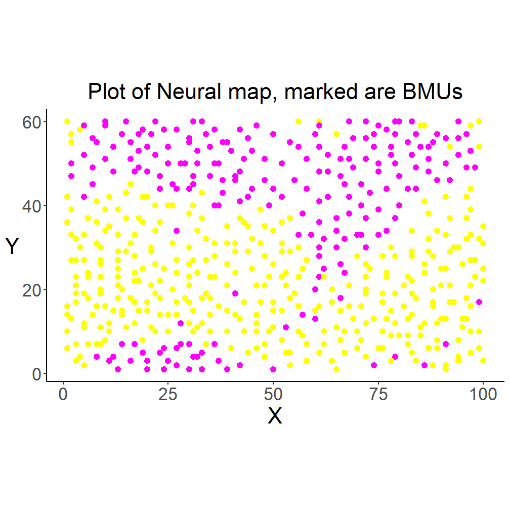

```r
ggobj=ProjectionBasedClustering::PlotProjectedPoints(
  res$BestMatches[,-1],
  Cls = classes$Class,

  BMUorProjected = T,
  main = 'Plot of Neural map, marked are BMUs')
```

- Plot of BMU’s shows that classes have been correctly placed in clusters, but there us next to no distinction or gaps between clusters.

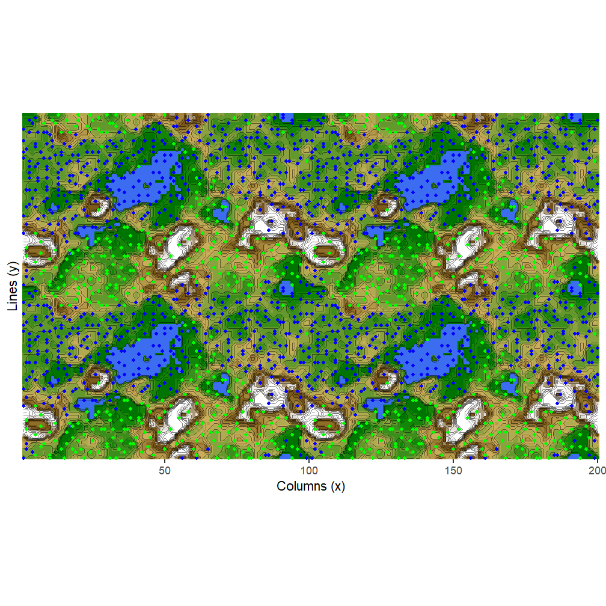

```r
plotMatrix(Ustarmatrix, Cls = classes$Class, res$BestMatches, Toroid = T)
```

Even with ground truth classes, their separation is not clear.

*Would you trust the predictions of the neural network from the previous task?*

However, we cannot be sure that the neural network does not actually reach the results in practice as it does on the test set. This would need to be further investigated, for example with more data.